# =====Part 3===== Data Quality

```r
#install.packages(data.table)
library(dplyr)
library(tibble)
library(lattice)
library(ggplot2)
library(extracat)
library(gridExtra)
library(data.table)
fread("NYPD_Complaint_Data_Historic.csv",na.strings="",colClasses = c(PARKS_NM="c",HADEVELOPT="c"))->df
```

[output not shown]

## ===Missing/Error Data Analysis===

This dataset has 24 variables and ~5.6 Million rows of complaints/events. 5 variables has data all valid. They are complaint number (CMPLNT_NUM), report date (RPT_DT), 3 digit offense classification code (KY_CD), level of offense (LAW_CAT_CD), jurisdiction responsible for incident (JURIS_DESC). The variable RPT_DT (the case reporting time) ranges from 2006-01-01 to 2016-12-31. The overall missing patterns are shown below. In this section, we investigate the missing patterns and possible errorness of variables that important to the understanting of the crime’s when, where and what.

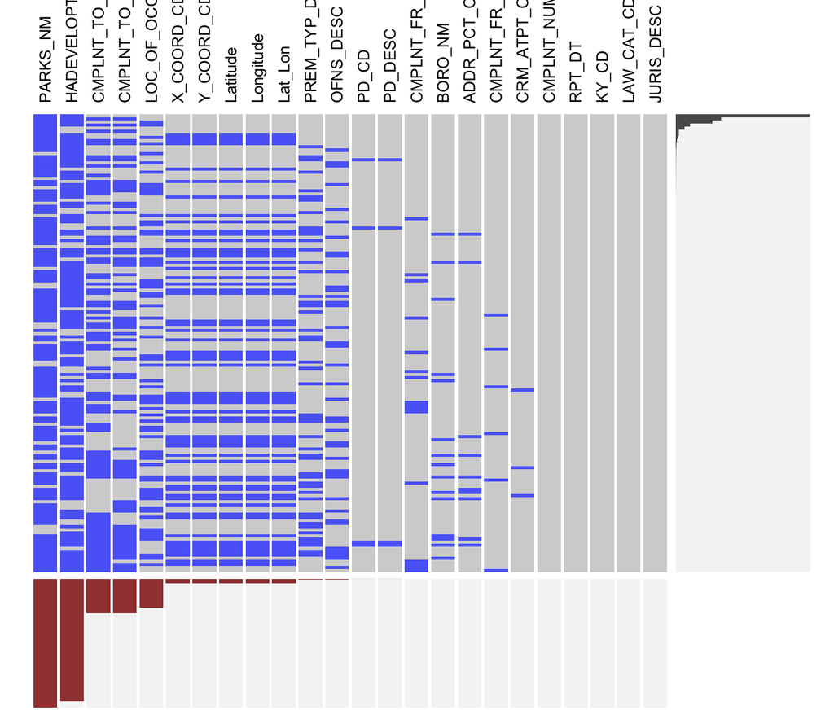

```r
visna(df,sort="b")
```

```r
#Show missing count and percentage, you can uncomment it if you like to see the statistics.

#for (i in 1:24) message(format(colnames(df)[i],justify="right",width=20),"\t",format(sum(is.na(dplyr::select(df,i))),digits=7),"\t",sum(is.na(dplyr::select(df,i)))*100/nrow(df))
```

===Missing in CMPLNT_FR_DT===

```r
#get the reporting dates of cases with starting dates missing
df%>%select(CMPLNT_FR_DT,RPT_DT)%>%filter(is.na(CMPLNT_FR_DT))%>%select(RPT_DT)%>%mutate(RPT_DT=as.Date(RPT_DT,format='%m/%d/%Y'))->tmp1

#boxplot of cases with points overlayed
tmp1%>%ggplot()+geom_boxplot(aes(x=1,y=RPT_DT))+geom_point(aes(x=1,y=RPT_DT),alpha=0.1)->p1
```

```r
df%>%select(CMPLNT_FR_DT,LAW_CAT_CD)%>%filter(is.na(CMPLNT_FR_DT))%>%select(LAW_CAT_CD)%>%mutate(LAW_CAT_CD=as.factor(LAW_CAT_CD))%>%group_by(LAW_CAT_CD)%>%dplyr::summarise(count=n())%>%mutate(RelFreq = count/sum(count))->tmp3; nr1=nrow(tmp3)
tmp3%>%mutate(type=replicate(nr1,"M_FR_DT"))->tmp3

df%>%select(LAW_CAT_CD)%>%mutate(LAW_CAT_CD=as.factor(LAW_CAT_CD))%>%group_by(LAW_CAT_CD)%>%dplyr::summarise(count=n())%>%mutate(RelFreq = count/sum(count))->tmp5; nr2=nrow(tmp5)
tmp5%>%mutate(type=replicate(nr2,"all"))->tmp5
rbind(tmp3,tmp5)->tmp3tmp5

tmp3tmp5%>%ggplot(aes(LAW_CAT_CD,RelFreq))+geom_bar(stat="identity")+scale_x_discrete(label=abbreviate)+
  coord_flip()+ylab("Level of Offense")+xlab("Relative Frequency")+facet_wrap(~type)->p2
```

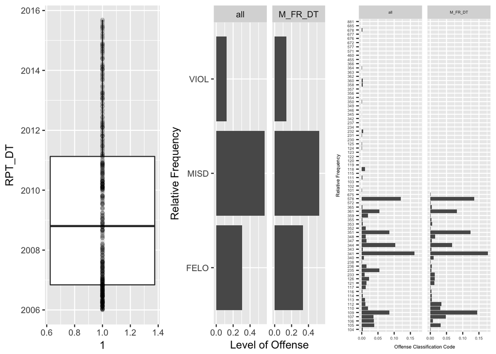

```r
df%>%select(CMPLNT_FR_DT,KY_CD)%>%filter(is.na(CMPLNT_FR_DT))%>%select(KY_CD)%>%mutate(KY_CD=as.factor(KY_CD))%>%group_by(KY_CD)%>%dplyr::summarise(count=n())%>%mutate(RelFreq = count/sum(count))->tmp2; nrr1=nrow(tmp2)
tmp2%>%mutate(type=replicate(nrr1,"M_FR_DT"))->tmp2

df%>%select(KY_CD)%>%mutate(KY_CD=as.factor(KY_CD))%>%group_by(KY_CD)%>%dplyr::summarise(count=n())%>%mutate(RelFreq = count/sum(count))->tmp4; nrr2=nrow(tmp4)
tmp4%>%mutate(type=replicate(nrr2,"all"))->tmp4
rbind(tmp2,tmp4)->tmp2tmp4

tmp2tmp4%>%ggplot(aes(KY_CD,RelFreq),na.rm=FALSE)+geom_bar(stat="identity")+theme(text = element_text(size=5))+
  coord_flip()+ylab("Offense Classification Code")+xlab("Relative Frequency")+facet_wrap(~type)->p3
grid.arrange(p1,p2,p3,nrow=1)
```

- There are total of 655 complaints missing CMPLNT_FR_DT, of which,
1. When looking at the RPT_DT (reporting date) although they look slightly clusted at the beginning around 2006 and less at the ending around 2016, the reporting dates still look pretty even over the period suggesting randomness of the missing against RPT_DT.
2. The frequency distrinution of LAW_CAT_CD shares the same pattern of that from all data.
3. The frequency distrinution of KY_CD shares the same pattern of that from all data.  
   ===Errors in CMPLNT_FR_DT===

```r
df%>%select(CMPLNT_FR_DT,CMPLNT_TO_DT,RPT_DT)%>%
  mutate(CMPLNT_FR_DT=as.Date(CMPLNT_FR_DT,format='%m/%d/%Y'),
         CMPLNT_TO_DT=as.Date(CMPLNT_TO_DT,format='%m/%d/%Y'),
         RPT_DT=as.Date(RPT_DT,format='%m/%d/%Y'))->df_3DT

df_3DT%>%filter(CMPLNT_FR_DT<=as.Date("1900-01-01"))->df_3DT_Year1900
df_3DT%>%filter(CMPLNT_FR_DT>=as.Date("1900-01-01") & CMPLNT_FR_DT<=as.Date("1920-01-01"))->df_3DT_Year1900to1920
df_3DT%>%filter(CMPLNT_FR_DT>=as.Date("1920-01-01") & CMPLNT_FR_DT<=as.Date("1960-01-01"))->df_3DT_Year1920to1960
df_3DT%>%filter(CMPLNT_FR_DT>=as.Date("1960-01-01") & CMPLNT_FR_DT<=as.Date("1980-01-01"))->df_3DT_Year1960to1980
df_3DT%>%filter(CMPLNT_FR_DT>=as.Date("1980-01-01") & CMPLNT_FR_DT<=as.Date("2000-01-01"))->df_3DT_Year1980to2000
df_3DT%>%filter(CMPLNT_FR_DT>=as.Date("2000-01-01") & CMPLNT_FR_DT<=as.Date("2006-01-01"))->df_3DT_Year2000to2006
```

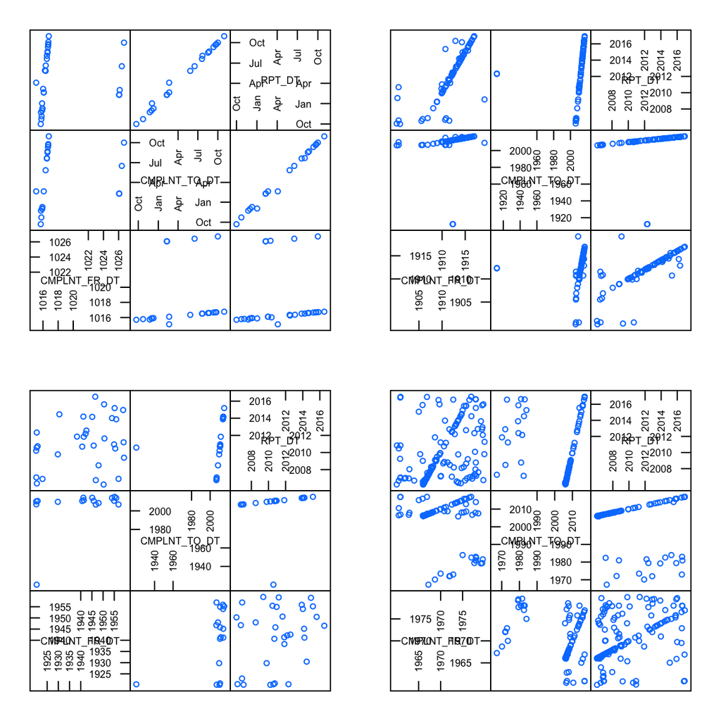

```r
#association between report date and complaint date indicating possible typo in recording the data
splom(df_3DT_Year1900,varname.cex = .5,axis.text.cex = 0.5,cex=.5,xlab=NULL)->pl1
splom(df_3DT_Year1900to1920,varname.cex = .5,axis.text.cex = .5,cex=.5,xlab=NULL)->pl2
splom(df_3DT_Year1920to1960,varname.cex = .5,axis.text.cex = .5,cex=.5,xlab=NULL)->pl3
splom(df_3DT_Year1960to1980,varname.cex = .5,axis.text.cex = .5,cex=.5,xlab=NULL)->pl4
grid.arrange(pl1,pl2,pl3,pl4,nrow=2)
```

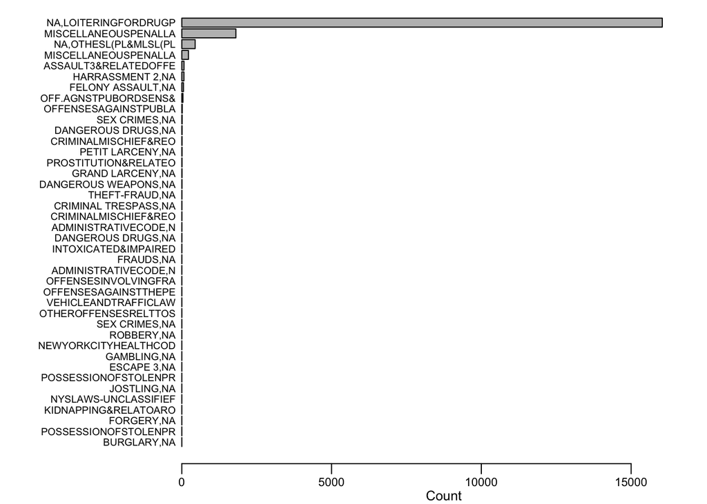

```r
#For cases with missing OFNS_DESC, how they distribute over the code KY_CD
df%>%
  select(KY_CD,OFNS_DESC)%>%
  filter(is.na(OFNS_DESC))%>%
  mutate(KY_CD=as.factor(KY_CD))%>%
  group_by(KY_CD)%>%dplyr::summarise(count=n())->tmp6

#Matching the code KY_CD with the OFNS_DESC
df%>%select(KY_CD,OFNS_DESC)%>%group_by(KY_CD)%>%
  dplyr::summarise(desc=paste(unique(OFNS_DESC),collapse=","))%>%
  mutate(KY_CD=as.factor(KY_CD))%>%arrange(desc)->match_code_desc

#showing the supposed OFNS_DESC that is missing with its KY_CD
merge(tmp6,match_code_desc,by.x="KY_CD",by.y="KY_CD")%>%arrange(desc(count))->match_bycount

par(mgp=c(1,0.3,0),mai=c(0.4,1.8,0.01,0.01))
data2<-match_bycount[order(match_bycount[,"count"]),]
barplot(data2[,"count"],names.arg=abbreviate(data2[,"desc"],minlength=20),cex.names = 0.6,cex.axis=0.7,cex.lab=0.8,horiz=TRUE,xlim=c(0,17500),las=1,xlab="Count")
```

* OFNS_DESC is the description of offense corresponding with key code KY_CD which is complete in the dataset. (Shouldn’t description leads to a code? Why there is missing in description but code is available?) Some case has 2 description but 1 code. some cases have different code but same description. Code and description map each other and valid match can be infered from the dataset. So the missing description can be retrieved from the valid mapping.

- The plot below shows cases with missing OFNS_DESC grouped by KY_CD and then with OFNS_DESC retrieved back from KY_CD.  
  ===Missing in geolocation===

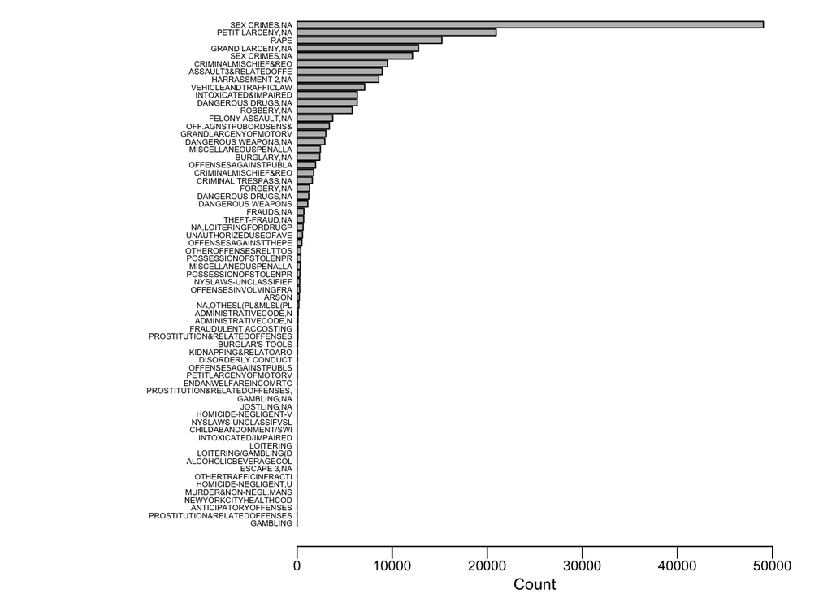

```r
#For cases with missing Latitude, how they distribute over the code KY_CD
df%>%
  select(KY_CD,Latitude)%>%
  filter(is.na(Latitude))%>%
  mutate(KY_CD=as.factor(KY_CD))%>%
  group_by(KY_CD)%>%dplyr::summarise(count=n())->tmp7

merge(tmp7,match_code_desc,by.x="KY_CD",by.y="KY_CD")%>%arrange(desc(count))->match_bycount2

#par(mar=c(4.1,15.1,2.1,2.1))
par(mgp=c(1,0.2,0),mai=c(0.4,2.5,0.01,0.5))
data2<-match_bycount2[order(match_bycount2[,"count"]),]
barplot(data2[,"count"],names.arg=abbreviate(data2[,"desc"],minlength=20),horiz=TRUE,cex.names = 0.4,cex.axis=0.7,cex.lab=0.8,xlim=c(0,50000),las=1,xlab="Count")
```

* The 5 geolocation variables have the same missing pattern as expected. So we only need to look at one of them to examine the missing. In the data document, it stated that “to protect victim identities, rape and sex crime offenses are not geocoded”. We want to see if the missing of geo variables are mostly related with those crime? Is there a lot of missing for other crimes too?

- The mising in geolocation is obviously not random. When examine the spatial pattern of the crimes, we have to bear in mind that particular crimes will not appear on the map due to missing not at random.  
  ===Missing in CRM_ATPT_CPTD_CD===
- CRM_ATPT_CPTD_CD is an indicator of whether crime attemped or complelted. Only 7 missing cases; 5483869 coded as completed, and 96159 cases indicated as attempted.  
  ===PREM_TYP_DESC===
- 70 levels of description of premises.  
  ===PARKS_NM===
- Most of the cases doesn’t not have this vairable mostly becasue it doesn’t apply. How much percent of real missing of park place, we don’t know.  
  ===HADEVELOPT===
- Don’t know what does this mean? It’s missing a lot too.  
  ===BORO_NM===
- 463 cases missing BORO_NM, of which 75 has valid location data and 388 doesn’t. Overall, 463 compare to 5M, ignorable.  
  ===ADDR_PCT_CD===
- 390 missing Ignorable. 77 distinct precincts.
- For some precints, they are counted in more than one borough, i.e., for some cases, they are in one borough while for other cases they are in another borough.